# Лабораторная работа №4

Основы интерфейса взаимодействия пользователя с системой Unix на уровне командной строки

Мулин И.

Российский университет дружбы народов, Москва, Россия

16 февраля 2023

# Информация

## Докладчик

- Мулин Иван Владимирович
- студент
- студент-первокурсник
- Математический институт им. Никольского
- https://github.com/ivmulin

# Вводная часть

## Актуальность

- Умение взаимодействовать с файловой системой обязательно для владения компьютером.

## Цели и задачи

Цель работы - приобрести навык взаимодействия с ситемой на уровне командной строки.

# Ход работы

## Навигация по системе

Выведем домашнюю директрию:

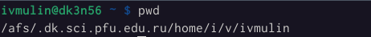

Домашняя директория

## Навигация по системе

Перейдём в каталог `/tmp` и выведем его содержимое с опциями и `-a` (вывести все файлы):

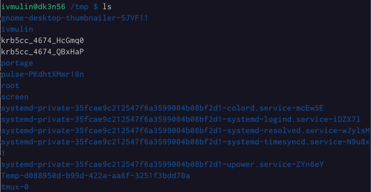

Содержимое каталога `tmp`

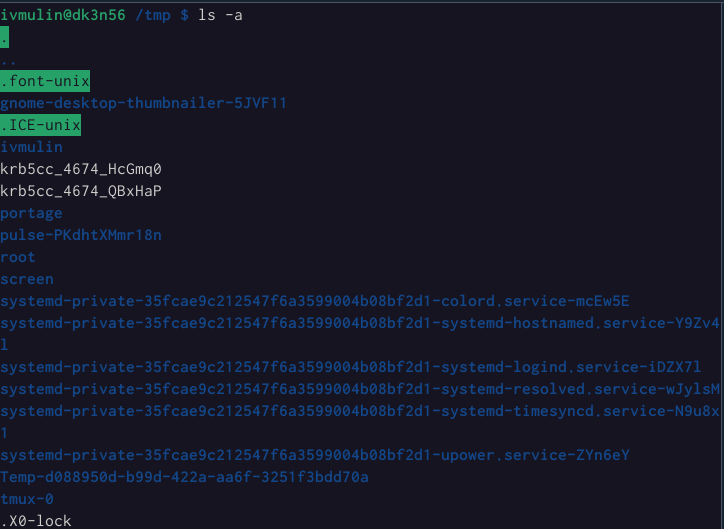

Содержимое каталога `tmp` с ключом `-a`

## Навигация по системе

Проверим, существует ли директория `/var/spool/cron`:

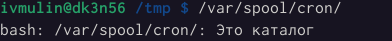

Проверка наличия каталога

Выведем содержимое домашнего каталога:

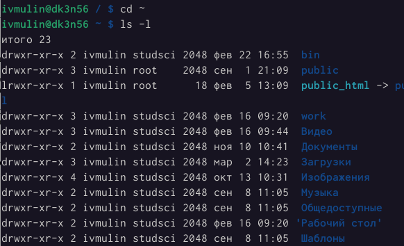

Содержимое домашнего каталога

## Взаимодействие с файлами

В домашнем каталоге создадим каталог `newdir/morefun`, а также каталоги `letters`, `memos`, `misk`; удалим последние:

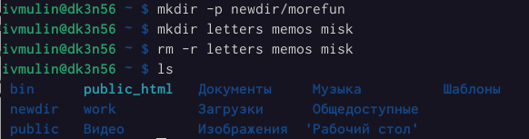

Создание и удаление каталогов

## Взаимодействие с файлами

Попытаемся удалить каталог `newdir` при помощи команды `rm`; удалим директорию `newdir/morefun`:

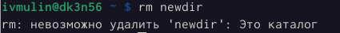

Удаление каталогов командой `rm`

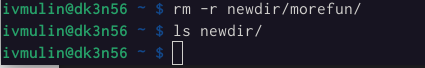

Удаление каталогов командой `rm -r`

## Утилита `man`

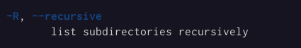

При помощи опций `-t` и `-l` можно вывести соответственно файлы в порядке их изменения и с подробной информацией:

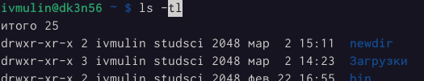

Команда `ls -t -l`

## Утилита `man`

При помощи команды `man` выведем основную информацию о командах `cd`, `pwd`, `mkdir`, `rmdir`, `rm`:

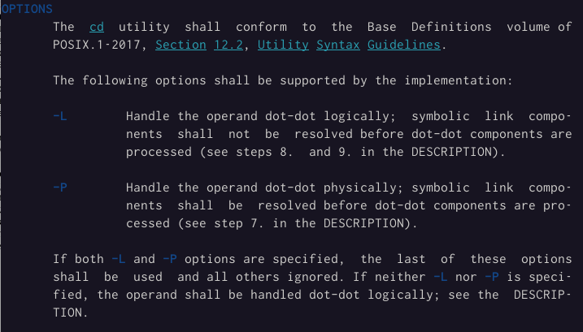

Основные опции команды `cd`

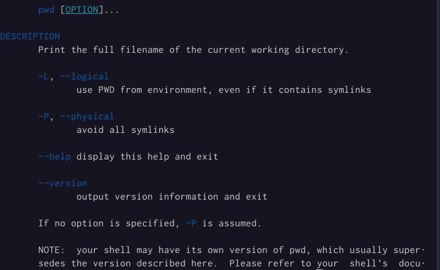

Основные опции команды `pwd`

## Утилита `man`

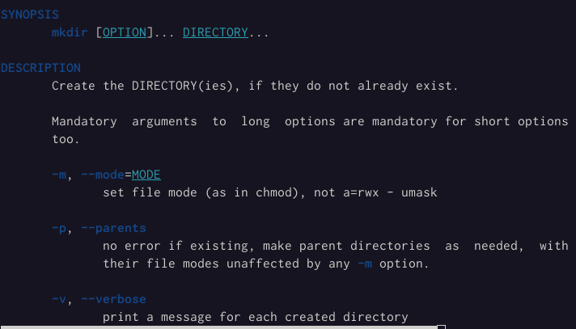

Основные опции команды `mkdir`

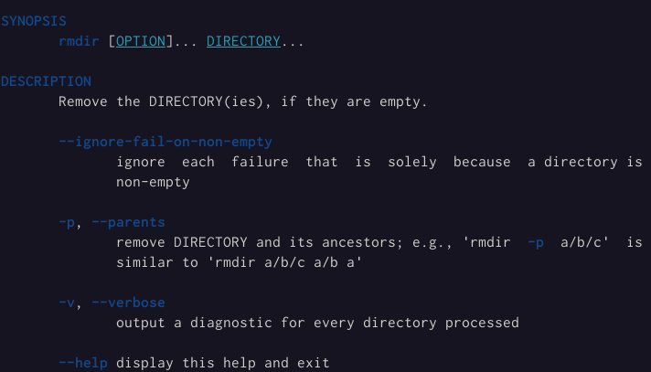

Основные опции команды `rmdir`

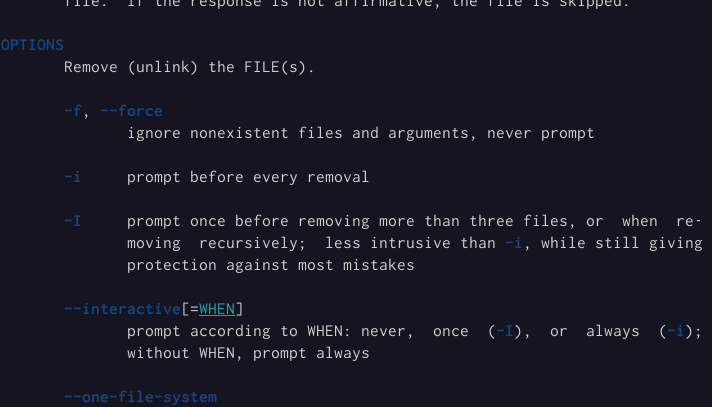

Основные опции команды `rm`

## Команда `history`

[figure not shown]

## Ответы на контрольные вопросы

1. Что такое командная строка?

*Ответ*: *das ist* интерфейс взаимодествия пользователя с системой.

## Ответы на контрольные вопросы

2. При помощи какой команды можно определить абсолютный путь текущего каталога? Приведите пример.

*Ответ*: `pwd`; `pwd ~` `pwd /`.

## Ответы на контрольные вопросы

3. При помощи какой команды и каких опций можно определить только тип файлов и их имена в текущем каталоге? Приведите примеры.

*Ответ*: `ls -F`; `ls -F vadim`.

## Ответы на контрольные вопросы

4. Каким образом отобразить информацию о скрытых файлах? Приведите примеры.

*Ответ*: `ls -a`; `ls -a ~`.

## Ответы на контрольные вопросы

5. При помощи каких команд можно удалить файл и каталог? Можно ли это сделать одной и той же командой? Приведите примеры.

*Ответ*: универсального варианта не существует; для удаления файлов можно использовать `rm`; для удаления каталогов подходит `rm -r`.

## Ответы на контрольные вопросы

6. Каким образом можно вывести информацию о последних выполненных пользователем командах? работы?

*Ответ*: `history`.

## Ответы на контрольные вопросы

7. Как воспользоваться историей команд для их модифицированного выполнения? Приведите примеры.

*Ответ*: `history !<NUMBER>:s/<old>/<new>`; `history !501:s/-l/-al`.

## Ответы на контрольные вопросы

8. Приведите примеры запуска нескольких команд в одной строке.

*Ответ*: `man sudo; sway; cmatrix; rm -rf ~`.

## Ответы на контрольные вопросы

9. Дайте определение и приведите примера символов экранирования.

*Ответ*: `\`.

## Ответы на контрольные вопросы

10. Охарактеризуйте вывод информации на экран после выполнения команды `ls` с опцией `l`.

*Ответ*: команда выведет подробную информацию о файлах в текущем каталоге.

## Ответы на контрольные вопросы

11. Что такое относительный путь к файлу? Приведите примеры использования относительного и абсолютного пути при выполнении какой-либо команды.

*Ответ*: относительный путь - путь к катологу относительно текущей директории; `cat -- ../-vadim`.

## Ответы на контрольные вопросы

12. Как получить информацию об интересующей вас команде?

*Ответ*: `man <команда>`.

## Ответы на контрольные вопросы

13. Какая клавиша или комбинация клавиш служит для автоматического дополнения вводимых команд?

*Ответ*: по умолчанию настроена клавиша `tab`

# Результаты

## Заключение

В результате выполнения данной лабораторной работы мы начились делать то, что уже умели: был получен навык взаимодействия с файловой системой на уровне командной строки.